# act_report

## Data Wrangling Report - Findings and Inferences

This report provides a brief summary of all insights from the data wrangling project. All findings will be displayed using several visualizations or tables. The explored data set is stored in "twitter_archive_master.csv".

```python
import pandas as pd
import matplotlib.pyplot as plt
```

```python
# loading the DataFrame
df = pd.read_csv('twitter_archive_master.csv')
```

First, the visualizations of tables will be displayed before we will dig deeper into the findings and interpretations.

```python
# Introduciton into desciptive statics of the data set
df.describe()
```

|  | tweet_id | rating_numerator | rating_denominator | img_num | p1_conf | retweet_count | favorite_count |
| --- | --- | --- | --- | --- | --- | --- | --- |
| count | 1.937000e+03 | 1937.000000 | 1937.0 | 1937.000000 | 1937.000000 | 1937.000000 | 1937.000000 |
| mean | 7.356789e+17 | 11.701084 | 10.0 | 1.202891 | 0.592733 | 2345.254517 | 8002.053175 |
| std | 6.759236e+16 | 41.259171 | 0.0 | 0.560983 | 0.272291 | 4205.925626 | 11800.293118 |
| min | 6.660209e+17 | 0.000000 | 10.0 | 1.000000 | 0.044333 | 11.000000 | 69.000000 |
| 25% | 6.757109e+17 | 10.000000 | 10.0 | 1.000000 | 0.360428 | 523.000000 | 1691.000000 |
| 50% | 7.081309e+17 | 11.000000 | 10.0 | 1.000000 | 0.586937 | 1131.000000 | 3573.000000 |
| 75% | 7.877176e+17 | 12.000000 | 10.0 | 1.000000 | 0.843911 | 2690.000000 | 10011.000000 |
| max | 8.924206e+17 | 1776.000000 | 10.0 | 4.000000 | 1.000000 | 74156.000000 | 150302.000000 |

**1.) The mean of the "rating_numerator" is 11.7**

The average rating of each dog post is 11.7 which does not make sense at the first glance. Initially, the best rating for each dog post should be out of 10. As declared in the introduction of this data wrangling project these ratings are normal as the WeRateDogs twitter page is famous for such ratings as these seem to be thes cutest out of the cutest from the whole globe. In this particular case is an irrational rating average acceptable as it is an essential part of this rating policy.

**2.) The "p1_conf" column shows an average probability of rating of 59%**

Conclusively, this means that every dog breed has been guessed with a probability rating of 59% on average. So almost every second rating might be incorrect. This must be considered in case this dataset will be used to analyze each dog breed.

**4.) Key Question 1: What kind of dogs are the most frequent ones?**

```
Text(0.5,1,'Most frequently posted dog types')
```

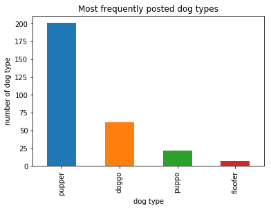

```python
df.kind.value_counts().plot(kind='bar')
plt.ylabel('number of dog type')
plt.xlabel('dog type')
plt.title('Most frequently posted dog types')
```

The barplot displays that most uploaded dog posts were from the dog type "pupper". As puppers are young dogs, they are considered to be very cute. This might be the reason why there have been so many pupper pictures uploaded. This dog species should go viral on the internet. As many twitter users have the intention to become famous, this might be a plausible motive to post predominantly pictures of puppers.

**5.) Key Question 2: What are the ten most common dog names according to this DataFrame?**

```
Text(0.5,0,'dog name')
```

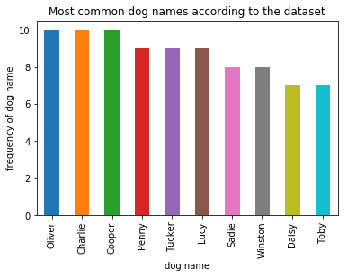

```python
df['name'].value_counts()[0:10].sort_values(ascending=False).plot(kind='bar')
plt.title('Most common dog names according to the dataset')
plt.ylabel('frequency of dog name')
plt.xlabel('dog name')
```

According to this dataset Oliver, Charlie and Cooper share the spot for the most common dog names. In this particular twitter community these names are predominant. So if you don't want to name your kid like a typicial dog be aware of the names mentioned above.